# Insurance claims fraud

Importing libraries.

```python
import warnings
warnings.filterwarnings('ignore')
```

```python
import numpy as np
import pandas as pd
import matplotlib.pyplot as plt
import seaborn as sns
%matplotlib inline
```

Step 1: Getting the dataset.

```python
dataset = pd.read_csv(r'C:\Users\91904\Desktop\Projects\insurance_claims.csv')
```

```python
print(dataset.shape)
dataset.head()
```

```
(1000, 40)
```

|  | months_as_customer | age | policy_number | policy_bind_date | policy_state | policy_csl | policy_deductable | policy_annual_premium | umbrella_limit | insured_zip | ... | police_report_available | total_claim_amount | injury_claim | property_claim | vehicle_claim | auto_make | auto_model | auto_year | fraud_reported | _c39 |
| --- | --- | --- | --- | --- | --- | --- | --- | --- | --- | --- | --- | --- | --- | --- | --- | --- | --- | --- | --- | --- | --- |
| 0 | 328 | 48 | 521585 | 17-10-2014 | OH | 250/500 | 1000 | 1406.91 | 0 | 466132 | ... | YES | 71610 | 6510 | 13020 | 52080 | Saab | 92x | 2004 | Y | NaN |
| 1 | 228 | 42 | 342868 | 27-06-2006 | IN | 250/500 | 2000 | 1197.22 | 5000000 | 468176 | ... | ? | 5070 | 780 | 780 | 3510 | Mercedes | E400 | 2007 | Y | NaN |
| 2 | 134 | 29 | 687698 | 06-09-2000 | OH | 100/300 | 2000 | 1413.14 | 5000000 | 430632 | ... | NO | 34650 | 7700 | 3850 | 23100 | Dodge | RAM | 2007 | N | NaN |
| 3 | 256 | 41 | 227811 | 25-05-1990 | IL | 250/500 | 2000 | 1415.74 | 6000000 | 608117 | ... | NO | 63400 | 6340 | 6340 | 50720 | Chevrolet | Tahoe | 2014 | Y | NaN |
| 4 | 228 | 44 | 367455 | 06-06-2014 | IL | 500/1000 | 1000 | 1583.91 | 6000000 | 610706 | ... | NO | 6500 | 1300 | 650 | 4550 | Accura | RSX | 2009 | N | NaN |

5 rows × 40 columns

```python
dataset.describe()
```

|  | months_as_customer | age | policy_number | policy_deductable | policy_annual_premium | umbrella_limit | insured_zip | capital-gains | capital-loss | incident_hour_of_the_day | number_of_vehicles_involved | bodily_injuries | witnesses | total_claim_amount | injury_claim | property_claim | vehicle_claim | auto_year | _c39 |
| --- | --- | --- | --- | --- | --- | --- | --- | --- | --- | --- | --- | --- | --- | --- | --- | --- | --- | --- | --- |
| count | 1000.000000 | 1000.000000 | 1000.000000 | 1000.000000 | 1000.000000 | 1.000000e+03 | 1000.000000 | 1000.000000 | 1000.000000 | 1000.000000 | 1000.00000 | 1000.000000 | 1000.000000 | 1000.00000 | 1000.000000 | 1000.000000 | 1000.000000 | 1000.000000 | 0.0 |
| mean | 203.954000 | 38.948000 | 546238.648000 | 1136.000000 | 1256.406150 | 1.101000e+06 | 501214.488000 | 25126.100000 | -26793.700000 | 11.644000 | 1.83900 | 0.992000 | 1.487000 | 52761.94000 | 7433.420000 | 7399.570000 | 37928.950000 | 2005.103000 | NaN |
| std | 115.113174 | 9.140287 | 257063.005276 | 611.864673 | 244.167395 | 2.297407e+06 | 71701.610941 | 27872.187708 | 28104.096686 | 6.951373 | 1.01888 | 0.820127 | 1.111335 | 26401.53319 | 4880.951853 | 4824.726179 | 18886.252893 | 6.015861 | NaN |
| min | 0.000000 | 19.000000 | 100804.000000 | 500.000000 | 433.330000 | -1.000000e+06 | 430104.000000 | 0.000000 | -111100.000000 | 0.000000 | 1.00000 | 0.000000 | 0.000000 | 100.00000 | 0.000000 | 0.000000 | 70.000000 | 1995.000000 | NaN |
| 25% | 115.750000 | 32.000000 | 335980.250000 | 500.000000 | 1089.607500 | 0.000000e+00 | 448404.500000 | 0.000000 | -51500.000000 | 6.000000 | 1.00000 | 0.000000 | 1.000000 | 41812.50000 | 4295.000000 | 4445.000000 | 30292.500000 | 2000.000000 | NaN |
| 50% | 199.500000 | 38.000000 | 533135.000000 | 1000.000000 | 1257.200000 | 0.000000e+00 | 466445.500000 | 0.000000 | -23250.000000 | 12.000000 | 1.00000 | 1.000000 | 1.000000 | 58055.00000 | 6775.000000 | 6750.000000 | 42100.000000 | 2005.000000 | NaN |
| 75% | 276.250000 | 44.000000 | 759099.750000 | 2000.000000 | 1415.695000 | 0.000000e+00 | 603251.000000 | 51025.000000 | 0.000000 | 17.000000 | 3.00000 | 2.000000 | 2.000000 | 70592.50000 | 11305.000000 | 10885.000000 | 50822.500000 | 2010.000000 | NaN |
| max | 479.000000 | 64.000000 | 999435.000000 | 2000.000000 | 2047.590000 | 1.000000e+07 | 620962.000000 | 100500.000000 | 0.000000 | 23.000000 | 4.00000 | 2.000000 | 3.000000 | 114920.00000 | 21450.000000 | 23670.000000 | 79560.000000 | 2015.000000 | NaN |

```python
dataset.describe(include='all')
```

|  | months_as_customer | age | policy_number | policy_bind_date | policy_state | policy_csl | policy_deductable | policy_annual_premium | umbrella_limit | insured_zip | ... | police_report_available | total_claim_amount | injury_claim | property_claim | vehicle_claim | auto_make | auto_model | auto_year | fraud_reported | _c39 |
| --- | --- | --- | --- | --- | --- | --- | --- | --- | --- | --- | --- | --- | --- | --- | --- | --- | --- | --- | --- | --- | --- |
| count | 1000.000000 | 1000.000000 | 1000.000000 | 1000 | 1000 | 1000 | 1000.000000 | 1000.000000 | 1.000000e+03 | 1000.000000 | ... | 1000 | 1000.00000 | 1000.000000 | 1000.000000 | 1000.000000 | 1000 | 1000 | 1000.000000 | 1000 | 0.0 |
| unique | NaN | NaN | NaN | 951 | 3 | 3 | NaN | NaN | NaN | NaN | ... | 3 | NaN | NaN | NaN | NaN | 14 | 39 | NaN | 2 | NaN |
| top | NaN | NaN | NaN | 05-08-1992 | OH | 250/500 | NaN | NaN | NaN | NaN | ... | ? | NaN | NaN | NaN | NaN | Saab | RAM | NaN | N | NaN |
| freq | NaN | NaN | NaN | 3 | 352 | 351 | NaN | NaN | NaN | NaN | ... | 343 | NaN | NaN | NaN | NaN | 80 | 43 | NaN | 753 | NaN |
| mean | 203.954000 | 38.948000 | 546238.648000 | NaN | NaN | NaN | 1136.000000 | 1256.406150 | 1.101000e+06 | 501214.488000 | ... | NaN | 52761.94000 | 7433.420000 | 7399.570000 | 37928.950000 | NaN | NaN | 2005.103000 | NaN | NaN |
| std | 115.113174 | 9.140287 | 257063.005276 | NaN | NaN | NaN | 611.864673 | 244.167395 | 2.297407e+06 | 71701.610941 | ... | NaN | 26401.53319 | 4880.951853 | 4824.726179 | 18886.252893 | NaN | NaN | 6.015861 | NaN | NaN |
| min | 0.000000 | 19.000000 | 100804.000000 | NaN | NaN | NaN | 500.000000 | 433.330000 | -1.000000e+06 | 430104.000000 | ... | NaN | 100.00000 | 0.000000 | 0.000000 | 70.000000 | NaN | NaN | 1995.000000 | NaN | NaN |
| 25% | 115.750000 | 32.000000 | 335980.250000 | NaN | NaN | NaN | 500.000000 | 1089.607500 | 0.000000e+00 | 448404.500000 | ... | NaN | 41812.50000 | 4295.000000 | 4445.000000 | 30292.500000 | NaN | NaN | 2000.000000 | NaN | NaN |
| 50% | 199.500000 | 38.000000 | 533135.000000 | NaN | NaN | NaN | 1000.000000 | 1257.200000 | 0.000000e+00 | 466445.500000 | ... | NaN | 58055.00000 | 6775.000000 | 6750.000000 | 42100.000000 | NaN | NaN | 2005.000000 | NaN | NaN |
| 75% | 276.250000 | 44.000000 | 759099.750000 | NaN | NaN | NaN | 2000.000000 | 1415.695000 | 0.000000e+00 | 603251.000000 | ... | NaN | 70592.50000 | 11305.000000 | 10885.000000 | 50822.500000 | NaN | NaN | 2010.000000 | NaN | NaN |
| max | 479.000000 | 64.000000 | 999435.000000 | NaN | NaN | NaN | 2000.000000 | 2047.590000 | 1.000000e+07 | 620962.000000 | ... | NaN | 114920.00000 | 21450.000000 | 23670.000000 | 79560.000000 | NaN | NaN | 2015.000000 | NaN | NaN |

11 rows × 40 columns

Step 2: Data preprocessing

```python
dataset.drop('_c39', axis=1,inplace=True)
```

```python
dataset.head()
```

|  | months_as_customer | age | policy_number | policy_bind_date | policy_state | policy_csl | policy_deductable | policy_annual_premium | umbrella_limit | insured_zip | ... | witnesses | police_report_available | total_claim_amount | injury_claim | property_claim | vehicle_claim | auto_make | auto_model | auto_year | fraud_reported |
| --- | --- | --- | --- | --- | --- | --- | --- | --- | --- | --- | --- | --- | --- | --- | --- | --- | --- | --- | --- | --- | --- |
| 0 | 328 | 48 | 521585 | 17-10-2014 | OH | 250/500 | 1000 | 1406.91 | 0 | 466132 | ... | 2 | YES | 71610 | 6510 | 13020 | 52080 | Saab | 92x | 2004 | Y |
| 1 | 228 | 42 | 342868 | 27-06-2006 | IN | 250/500 | 2000 | 1197.22 | 5000000 | 468176 | ... | 0 | ? | 5070 | 780 | 780 | 3510 | Mercedes | E400 | 2007 | Y |
| 2 | 134 | 29 | 687698 | 06-09-2000 | OH | 100/300 | 2000 | 1413.14 | 5000000 | 430632 | ... | 3 | NO | 34650 | 7700 | 3850 | 23100 | Dodge | RAM | 2007 | N |
| 3 | 256 | 41 | 227811 | 25-05-1990 | IL | 250/500 | 2000 | 1415.74 | 6000000 | 608117 | ... | 2 | NO | 63400 | 6340 | 6340 | 50720 | Chevrolet | Tahoe | 2014 | Y |
| 4 | 228 | 44 | 367455 | 06-06-2014 | IL | 500/1000 | 1000 | 1583.91 | 6000000 | 610706 | ... | 1 | NO | 6500 | 1300 | 650 | 4550 | Accura | RSX | 2009 | N |

5 rows × 39 columns

Checking for null values.

```python
dataset.isna().sum()
```

```
months_as_customer             0
age                            0
policy_number                  0
policy_bind_date               0
policy_state                   0
policy_csl                     0
policy_deductable              0
policy_annual_premium          0
umbrella_limit                 0
insured_zip                    0
insured_sex                    0
insured_education_level        0
insured_occupation             0
insured_hobbies                0
insured_relationship           0
capital-gains                  0
capital-loss                   0
incident_date                  0
incident_type                  0
collision_type                 0
incident_severity              0
authorities_contacted          0
incident_state                 0
incident_city                  0
incident_location              0
incident_hour_of_the_day       0
number_of_vehicles_involved    0
property_damage                0
bodily_injuries                0
witnesses                      0
police_report_available        0
total_claim_amount             0
injury_claim                   0
property_claim                 0
vehicle_claim                  0
auto_make                      0
auto_model                     0
auto_year                      0
fraud_reported                 0
dtype: int64
```

No null values present.But, i have seen there are '?' in column police_report_available. Let's check for other columns too.

```python
dataset.nunique(axis=0)
```

```
months_as_customer              391
age                              46
policy_number                  1000
policy_bind_date                951
policy_state                      3
policy_csl                        3
policy_deductable                 3
policy_annual_premium           991
umbrella_limit                   11
insured_zip                     995
insured_sex                       2
insured_education_level           7
insured_occupation               14
insured_hobbies                  20
insured_relationship              6
capital-gains                   338
capital-loss                    354
incident_date                    60
incident_type                     4
collision_type                    4
incident_severity                 4
authorities_contacted             5
incident_state                    7
incident_city                     7
incident_location              1000
incident_hour_of_the_day         24
number_of_vehicles_involved       4
property_damage                   3
bodily_injuries                   3
witnesses                         4
police_report_available           3
total_claim_amount              763
injury_claim                    638
property_claim                  626
vehicle_claim                   726
auto_make                        14
auto_model                       39
auto_year                        21
fraud_reported                    2
dtype: int64
```

```python
dataset.columns
```

```
Index(['months_as_customer', 'age', 'policy_number', 'policy_bind_date',
       'policy_state', 'policy_csl', 'policy_deductable',
       'policy_annual_premium', 'umbrella_limit', 'insured_zip', 'insured_sex',
       'insured_education_level', 'insured_occupation', 'insured_hobbies',
       'insured_relationship', 'capital-gains', 'capital-loss',
       'incident_date', 'incident_type', 'collision_type', 'incident_severity',
       'authorities_contacted', 'incident_state', 'incident_city',
       'incident_location', 'incident_hour_of_the_day',
       'number_of_vehicles_involved', 'property_damage', 'bodily_injuries',
       'witnesses', 'police_report_available', 'total_claim_amount',
       'injury_claim', 'property_claim', 'vehicle_claim', 'auto_make',
       'auto_model', 'auto_year', 'fraud_reported'],
      dtype='object')
```

```python
column = ['months_as_customer', 'age', 'policy_number', 'policy_bind_date',
       'policy_state', 'policy_csl', 'policy_deductable',
       'policy_annual_premium', 'umbrella_limit', 'insured_zip', 'insured_sex',
       'insured_education_level', 'insured_occupation', 'insured_hobbies',
       'insured_relationship', 'capital-gains', 'capital-loss',
       'incident_date', 'incident_type', 'collision_type', 'incident_severity',
       'authorities_contacted', 'incident_state', 'incident_city',
       'incident_location', 'incident_hour_of_the_day',
       'number_of_vehicles_involved', 'property_damage', 'bodily_injuries',
       'witnesses', 'police_report_available', 'total_claim_amount',
       'injury_claim', 'property_claim', 'vehicle_claim', 'auto_make',
       'auto_model', 'auto_year', 'fraud_reported']
```

```python
for i in range(len(column)):
    j = column[i]
    print(j)
    print(dataset[j].unique())
```

[output not shown]

[output cut: 1152 more lines]

```
 42490 26670 25690  4860 61040 52500]
auto_make
['Saab' 'Mercedes' 'Dodge' 'Chevrolet' 'Accura' 'Nissan' 'Audi' 'Toyota'
 'Ford' 'Suburu' 'BMW' 'Jeep' 'Honda' 'Volkswagen']
auto_model
['92x' 'E400' 'RAM' 'Tahoe' 'RSX' '95' 'Pathfinder' 'A5' 'Camry' 'F150'
 'A3' 'Highlander' 'Neon' 'MDX' 'Maxima' 'Legacy' 'TL' 'Impreza'
 'Forrestor' 'Escape' 'Corolla' '3 Series' 'C300' 'Wrangler' 'M5' 'X5'
 'Civic' 'Passat' 'Silverado' 'CRV' '93' 'Accord' 'X6' 'Malibu' 'Fusion'
 'Jetta' 'ML350' 'Ultima' 'Grand Cherokee']
auto_year
[2004 2007 2014 2009 2003 2012 2015 1996 2002 2006 2000 2010 1999 2011
 2005 2008 1995 2001 1998 1997 2013]
fraud_reported
['Y' 'N']
```

```python
(dataset[dataset.columns]=='?').sum()
```

```
months_as_customer               0
age                              0
policy_number                    0
policy_bind_date                 0
policy_state                     0
policy_csl                       0
policy_deductable                0
policy_annual_premium            0
umbrella_limit                   0
insured_zip                      0
insured_sex                      0
insured_education_level          0
insured_occupation               0
insured_hobbies                  0
insured_relationship             0
capital-gains                    0
capital-loss                     0
incident_date                    0
incident_type                    0
collision_type                 178
incident_severity                0
authorities_contacted            0
incident_state                   0
incident_city                    0
incident_location                0
incident_hour_of_the_day         0
number_of_vehicles_involved      0
property_damage                360
bodily_injuries                  0
witnesses                        0
police_report_available        343
total_claim_amount               0
injury_claim                     0
property_claim                   0
vehicle_claim                    0
auto_make                        0
auto_model                       0
auto_year                        0
fraud_reported                   0
dtype: int64
```

So, we can see column collision_type, property_damage and police_report_available contains '?'.

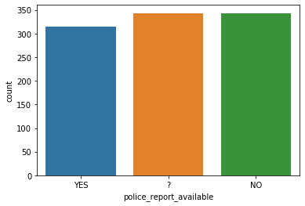

```python
sns.countplot(dataset['police_report_available'])
```

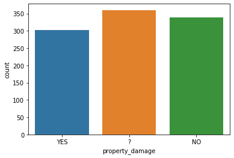

```python
sns.countplot(dataset['property_damage'])
```

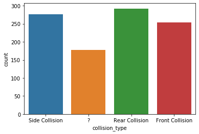

```python
sns.countplot(dataset['collision_type'])
```

```python
dataset = dataset.replace('?',np.NaN)
```

```python
dataset['police_report_available'].fillna(dataset['police_report_available'].mode()[0], inplace = True)
dataset['property_damage'].fillna(dataset['property_damage'].mode()[0], inplace = True)
dataset['collision_type'].fillna(dataset['collision_type'].mode()[0], inplace = True)
```

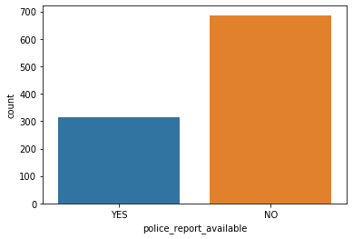

```python
sns.countplot(dataset['police_report_available'])
```

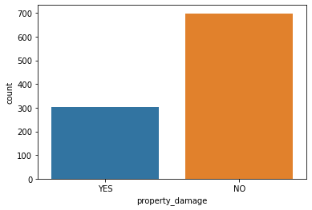

```python
sns.countplot(dataset['property_damage'])
```

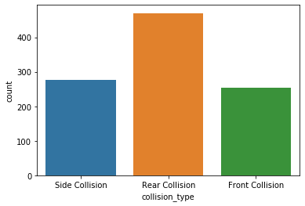

```python
sns.countplot(dataset['collision_type'])
```

Step 3: EDA.

First let's check for the dataset distribution whether it is a balanced or imbalanced dataset.

```python
import plotly
```

```python
from plotly import graph_objects as go
from plotly import offline as py
```

```python
fraud = dataset['fraud_reported'].value_counts()
```

```python
label = fraud.index
size = fraud.values
```

```python
donut = go.Pie(values=size, labels=label, hole=0.6, name='Dataset Distribution')
```

```python
layout = go.Layout(title='Fraud data distribution')
```

```python
fig = go.Figure(data=[donut],layout=layout)
```

```python
py.iplot(fig)
```

[interactive chart not shown]

From this visualisation we can say our dataset is imbalanced.

Let's check for which incident type most fraud where reported.

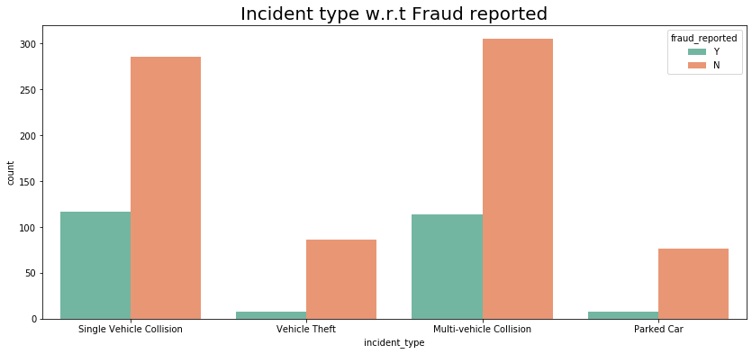

```python
plt.figure(figsize=(14,6))
sns.countplot(dataset['incident_type'],hue=dataset['fraud_reported'],palette='Set2')
plt.title('Incident type w.r.t Fraud reported', fontsize = 20)
plt.show()
```

From the above visualisation we can see most of the fraud claims where reported from single vehicle and multi-vehicle collision.

```python
from plotly.offline import download_plotlyjs, init_notebook_mode, plot, iplot
```

```python
init_notebook_mode(connected=True)
```

```python
data = dataset.groupby('policy_state')
```

```python
data_value = data.sum()
```

Plotting total claims amount w.r.t to states.

```python
data_value
```

| policy_state | months_as_customer | age | policy_number | policy_deductable | policy_annual_premium | umbrella_limit | insured_zip | capital-gains | capital-loss | incident_hour_of_the_day | number_of_vehicles_involved | bodily_injuries | witnesses | total_claim_amount | injury_claim | property_claim | vehicle_claim | auto_year |
| --- | --- | --- | --- | --- | --- | --- | --- | --- | --- | --- | --- | --- | --- | --- | --- | --- | --- | --- |
| IL | 68705 | 13258 | 174339338 | 388000 | 423559.80 | 406000000 | 168755772 | 7598800 | -8378600 | 3886 | 645 | 341 | 490 | 17861330 | 2588630 | 2500720 | 12771980 | 677625 |
| IN | 63720 | 11997 | 174374227 | 339000 | 389172.29 | 330000000 | 156163543 | 7851800 | -8953600 | 3539 | 559 | 287 | 465 | 16432160 | 2339650 | 2260870 | 11831640 | 621771 |
| OH | 71529 | 13693 | 197525083 | 409000 | 443674.06 | 365000000 | 176295173 | 9675500 | -9461500 | 4219 | 635 | 364 | 532 | 18468450 | 2505140 | 2637980 | 13325330 | 705707 |

```python
map_plot = dict(type = 'choropleth',
            locations = ['IL','IN','OH'],
            locationmode = 'USA-states',
            colorscale= 'Portland',
            text= ['IL claim amt','IN claim amt','OH claim amt'],
            z=[17861330,16432160,18468450],
            colorbar = {'title':'Total Claims amt'})
```

```python
layout = dict(geo = {'scope':'usa'})
```

```python
choromap = go.Figure(data = [map_plot],layout = layout)
```

```python
iplot(choromap)
```

[interactive chart not shown]

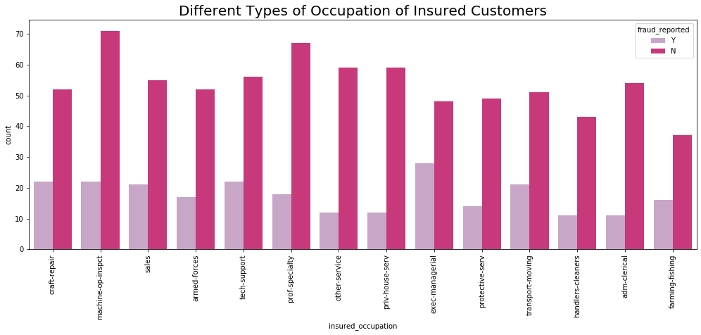

```python
plt.figure(figsize=(17,6))
sns.countplot(dataset['insured_occupation'],hue=dataset['fraud_reported'],palette='PuRd')
plt.title('Different Types of Occupation of Insured Customers', fontsize = 20)
plt.xticks(rotation = 90)
plt.show()
```

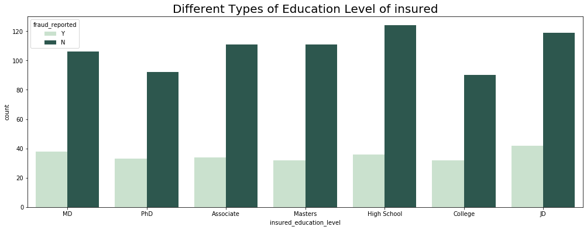

```python
plt.figure(figsize=(17,6))
sns.countplot(dataset['insured_education_level'],hue=dataset['fraud_reported'],palette="ch:2.5,-.2,dark=.3")
plt.title('Different Types of Education Level of insured', fontsize = 20)
plt.show()
```

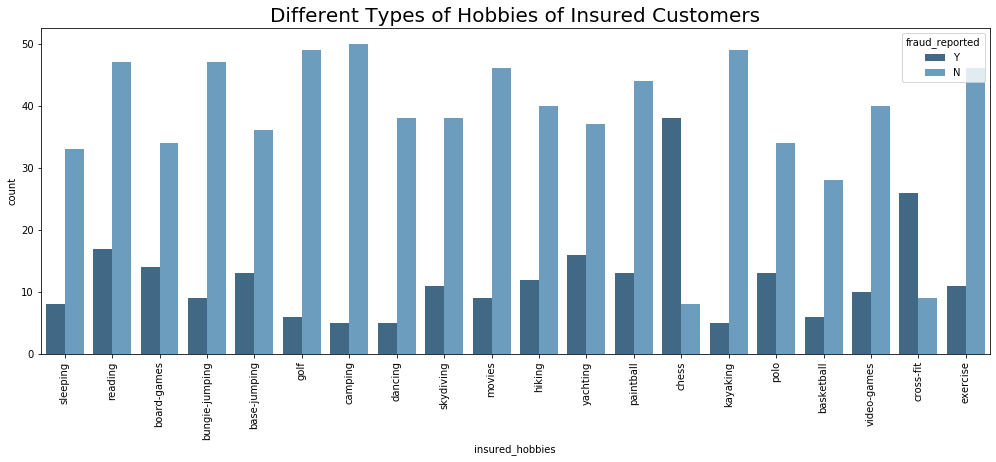

```python
plt.figure(figsize=(17,6))
sns.countplot(dataset['insured_hobbies'],hue=dataset['fraud_reported'],palette='Blues_d')
plt.title('Different Types of Hobbies of Insured Customers', fontsize = 20)
plt.xticks(rotation = 90)
plt.show()
```

Step 4: Handling categorical data.

```python
dataset['fraud_reported'] = dataset['fraud_reported'].replace(('Y','N'),(1,0))
```

Mean encoding auto_make varaible.

```python
dataset[['auto_make','fraud_reported']].groupby(['auto_make'], as_index=False).mean().sort_values(by='fraud_reported',
                                                                                                 ascending=False)
```

|  | auto_make | fraud_reported |
| --- | --- | --- |
| 8 | Mercedes | 0.338462 |
| 5 | Ford | 0.305556 |
| 1 | Audi | 0.304348 |
| 13 | Volkswagen | 0.279412 |
| 2 | BMW | 0.277778 |
| 3 | Chevrolet | 0.276316 |
| 6 | Honda | 0.254545 |
| 4 | Dodge | 0.250000 |
| 11 | Suburu | 0.237500 |
| 10 | Saab | 0.225000 |
| 0 | Accura | 0.191176 |
| 12 | Toyota | 0.185714 |
| 9 | Nissan | 0.179487 |
| 7 | Jeep | 0.164179 |

```python
dataset['auto_make'] = dataset['auto_make'].replace(('Mercedes','Ford','Audi','Volkswagen','BMW','Chevrolet','Honda',
                                                    'Dodge','Suburu','Saab','Accura','Toyota','Nissan','Jeep'),(0.33,
                                                     0.305,0.304,0.279,0.277,0.276,0.254,0.250,0.23,0.22,
                                                     0.19,0.18,0.17,0.16))
```

Mean encoding auto_model.

```python
dataset[['auto_model','fraud_reported']].groupby(['auto_model'], as_index=False).mean().sort_values(by='fraud_reported',
                                                                                                 ascending=False)
```

|  | auto_model | fraud_reported |
| --- | --- | --- |
| 38 | X6 | 0.437500 |
| 32 | Silverado | 0.409091 |
| 24 | ML350 | 0.400000 |
| 7 | C300 | 0.388889 |
| 34 | Tahoe | 0.375000 |
| 14 | F150 | 0.370370 |
| 10 | Civic | 0.363636 |
| 5 | A5 | 0.343750 |
| 22 | M5 | 0.333333 |
| 30 | RAM | 0.325581 |
| 37 | X5 | 0.304348 |
| 19 | Impreza | 0.300000 |
| 26 | Maxima | 0.291667 |
| 15 | Forrestor | 0.285714 |
| 16 | Fusion | 0.285714 |
| 1 | 92x | 0.285714 |
| 20 | Jetta | 0.285714 |
| 28 | Passat | 0.272727 |
| 18 | Highlander | 0.272727 |
| 4 | A3 | 0.270270 |
| 12 | E400 | 0.259259 |
| 13 | Escape | 0.250000 |
| 17 | Grand Cherokee | 0.240000 |
| 6 | Accord | 0.230769 |
| 23 | MDX | 0.222222 |
| 2 | 93 | 0.200000 |
| 33 | TL | 0.200000 |
| 3 | 95 | 0.185185 |
| 27 | Neon | 0.162162 |
| 21 | Legacy | 0.156250 |
| 8 | CRV | 0.150000 |
| 11 | Corolla | 0.150000 |
| 9 | Camry | 0.142857 |
| 35 | Ultima | 0.130435 |
| 29 | Pathfinder | 0.129032 |
| 36 | Wrangler | 0.119048 |
| 25 | Malibu | 0.100000 |
| 31 | RSX | 0.083333 |
| 0 | 3 Series | 0.055556 |

```python
dataset['auto_model'] = dataset['auto_model'].replace((['X6', 'Silverado', 'ML350', 'C300', 'Tahoe', 'F150', 'Civic', 'A5',
       'M5', 'RAM', 'X5', 'Impreza', 'Maxima', 'Forrestor', 'Fusion',
       '92x', 'Jetta', 'Passat', 'Highlander', 'A3', 'E400', 'Escape',
       'Grand Cherokee', 'Accord', 'MDX', '93', 'TL', '95', 'Neon',
       'Legacy', 'CRV', 'Corolla', 'Camry', 'Ultima', 'Pathfinder',
       'Wrangler', 'Malibu', 'RSX', '3 Series']),([0.4375    , 0.40909091, 0.4       , 0.38888889, 0.375     ,
       0.37037037, 0.36363636, 0.34375   , 0.33333333, 0.3255814 ,
       0.30434783, 0.3       , 0.29166667, 0.28571429, 0.28571429,
       0.28571429, 0.28571429, 0.27272727, 0.27272727, 0.27027027,
       0.25925926, 0.25      , 0.24      , 0.23076923, 0.22222222,
       0.2       , 0.2       , 0.18518519, 0.16216216, 0.15625   ,
       0.15      , 0.15      , 0.14285714, 0.13043478, 0.12903226,
       0.11904762, 0.1       , 0.08333333, 0.05555556]))
```

Mean encoding police_report_available.

```python
dataset[['police_report_available','fraud_reported']].groupby(['police_report_available'], as_index=False).mean().sort_values(['fraud_reported'],ascending=False)
```

|  | police_report_available | fraud_reported |
| --- | --- | --- |
| 0 | NO | 0.255102 |
| 1 | YES | 0.229299 |

```python
dataset['police_report_available'] = dataset['police_report_available'].replace(('NO','YES'),(0.25,0.22))
```

Mean encoding property_damage.

```python
dataset[['property_damage','fraud_reported']].groupby(['property_damage'], as_index=False).mean().sort_values(['property_damage'],
                                                                                                             ascending=False)
```

|  | property_damage | fraud_reported |
| --- | --- | --- |
| 1 | YES | 0.258278 |
| 0 | NO | 0.242120 |

```python
dataset['property_damage'] = dataset['property_damage'].replace(('YES','NO'),(0.25,0.24))
```

Mean encoding incident_city.

```python
dataset[['incident_city','fraud_reported']].groupby(['incident_city'],as_index=False).mean().sort_values(['incident_city'],
                                                                                                         ascending=False)
```

|  | incident_city | fraud_reported |
| --- | --- | --- |
| 6 | Springfield | 0.242038 |
| 5 | Riverwood | 0.223881 |
| 4 | Northbrook | 0.221311 |
| 3 | Northbend | 0.234483 |
| 2 | Hillsdale | 0.248227 |
| 1 | Columbus | 0.261745 |
| 0 | Arlington | 0.289474 |

```python
dataset['incident_city'] = dataset['incident_city'].replace(('Springfield', 'Riverwood', 'Northbrook', 'Northbend', 'Hillsdale',
       'Columbus', 'Arlington'),(0.24203822, 0.2238806 , 0.22131148, 0.23448276, 0.24822695,
       0.26174497, 0.28947368))
```

Mean encoding incident_state.

```python
dataset[['incident_state','fraud_reported']].groupby(['incident_state'], as_index=False).mean().sort_values(['fraud_reported'],
                                                                                                           ascending=False)
```

|  | incident_state | fraud_reported |
| --- | --- | --- |
| 2 | OH | 0.434783 |
| 0 | NC | 0.309091 |
| 4 | SC | 0.294355 |
| 3 | PA | 0.266667 |
| 5 | VA | 0.227273 |
| 1 | NY | 0.221374 |
| 6 | WV | 0.179724 |

```python
dataset['incident_state'] = dataset['incident_state'].replace(('OH','NC','SC','PA','VA','NY','WV'),
                                                             (0.43,0.30,0.29,0.26,0.22,0.22,0.17))
```

Mean encoding authorities_contacted.

```python
dataset[['authorities_contacted','fraud_reported']].groupby(['authorities_contacted'],as_index=False).mean().sort_values(['fraud_reported'],
                                                                                                                        ascending=False)
```

|  | authorities_contacted | fraud_reported |
| --- | --- | --- |
| 3 | Other | 0.318182 |
| 0 | Ambulance | 0.290816 |
| 1 | Fire | 0.269058 |
| 4 | Police | 0.208904 |
| 2 | None | 0.065934 |

```python
dataset['authorities_contacted'] = dataset['authorities_contacted'].replace(('Other','Ambulance','Fire','Police','None'),
                                                                            (0.31,0.29,0.26,0.20,0.06))
```

Mean encoding incident_severity.

```python
dataset[['incident_severity','fraud_reported']].groupby(['incident_severity'],as_index=False).mean().sort_values(['incident_severity'],
                                                                                                                ascending=False)
```

|  | incident_severity | fraud_reported |
| --- | --- | --- |
| 3 | Trivial Damage | 0.066667 |
| 2 | Total Loss | 0.128571 |
| 1 | Minor Damage | 0.107345 |
| 0 | Major Damage | 0.605072 |

```python
dataset['incident_severity'] = dataset['incident_severity'].replace(('Trivial Damage','Total Loss','Minor Damage','Major Damage'),
                                                                   (0.06,0.12,0.10,0.60))
```

Mean encoding collision_type.

```python
dataset[['collision_type','fraud_reported']].groupby(['collision_type'], as_index=False).mean().sort_values(['fraud_reported'],
                                                                                                           ascending=False)
```

|  | collision_type | fraud_reported |
| --- | --- | --- |
| 0 | Front Collision | 0.275591 |
| 2 | Side Collision | 0.253623 |
| 1 | Rear Collision | 0.227660 |

```python
dataset['collision_type'] = dataset['collision_type'].replace(('Front Collision','Side Collision','Rear Collision'),
                                                             (0.27,0.25,0.22))
```

Mean encoding incident_type.

```python
dataset[['incident_type','fraud_reported']].groupby(['incident_type'], as_index=False).mean().sort_values(['fraud_reported'],
                                                                                                         ascending=False)
```

|  | incident_type | fraud_reported |
| --- | --- | --- |
| 2 | Single Vehicle Collision | 0.290323 |
| 0 | Multi-vehicle Collision | 0.272076 |
| 1 | Parked Car | 0.095238 |
| 3 | Vehicle Theft | 0.085106 |

```python
dataset['incident_type'] = dataset['incident_type'].replace(('Single Vehicle Collision', 'Multi-vehicle Collision',
                                                            'Parked Car', 'Vehicle Theft'),(0.29,0.27,0.09,0.08))
```

Mean encoding insured_relationship.

```python
dataset[['insured_relationship','fraud_reported']].groupby(['insured_relationship'],as_index=False).mean().sort_values(['fraud_reported'],
                                                                                                                      ascending=False)
```

|  | insured_relationship | fraud_reported |
| --- | --- | --- |
| 2 | other-relative | 0.293785 |
| 5 | wife | 0.270968 |
| 1 | not-in-family | 0.258621 |
| 4 | unmarried | 0.241135 |
| 3 | own-child | 0.213115 |
| 0 | husband | 0.205882 |

```python
dataset['insured_relationship'] = dataset['insured_relationship'].replace(('other-relative','wife','not-in-family',
                                                                          'unmarried','own-child','husband'),(0.29,0.27,
                                                                                                             0.25,0.24,
                                                                                                             0.21,0.20))
```

```python
dataset[['insured_hobbies','fraud_reported']].groupby(['insured_hobbies'],as_index=False).mean().sort_values(['fraud_reported'],
                                                                                                                      ascending=False)
```

|  | insured_hobbies | fraud_reported |
| --- | --- | --- |
| 5 | chess | 0.826087 |
| 6 | cross-fit | 0.742857 |
| 19 | yachting | 0.301887 |
| 2 | board-games | 0.291667 |
| 14 | polo | 0.276596 |
| 15 | reading | 0.265625 |
| 0 | base-jumping | 0.265306 |
| 10 | hiking | 0.230769 |
| 13 | paintball | 0.228070 |
| 16 | skydiving | 0.224490 |
| 18 | video-games | 0.200000 |
| 17 | sleeping | 0.195122 |
| 8 | exercise | 0.192982 |
| 1 | basketball | 0.176471 |
| 12 | movies | 0.163636 |
| 3 | bungie-jumping | 0.160714 |
| 7 | dancing | 0.116279 |
| 9 | golf | 0.109091 |
| 11 | kayaking | 0.092593 |
| 4 | camping | 0.090909 |

```python
dataset['insured_hobbies'] = dataset['insured_hobbies'].replace((['chess', 'cross-fit', 'yachting', 'board-games', 'polo', 'reading',
       'base-jumping', 'hiking', 'paintball', 'skydiving', 'video-games',
       'sleeping', 'exercise', 'basketball', 'movies', 'bungie-jumping',
       'dancing', 'golf', 'kayaking', 'camping']),([0.82608696, 0.74285714, 0.30188679, 0.29166667, 0.27659574,
       0.265625  , 0.26530612, 0.23076923, 0.22807018, 0.2244898 ,
       0.2       , 0.19512195, 0.19298246, 0.17647059, 0.16363636,
       0.16071429, 0.11627907, 0.10909091, 0.09259259, 0.09090909]))
```

Mean encoding insured_occupation.

```python
dataset[['insured_occupation','fraud_reported']].groupby(['insured_occupation'],as_index=False).mean().sort_values(['fraud_reported'],
                                                                                                                      ascending=False)
```

|  | insured_occupation | fraud_reported |
| --- | --- | --- |
| 3 | exec-managerial | 0.368421 |
| 4 | farming-fishing | 0.301887 |
| 2 | craft-repair | 0.297297 |
| 13 | transport-moving | 0.291667 |
| 12 | tech-support | 0.282051 |
| 11 | sales | 0.276316 |
| 1 | armed-forces | 0.246377 |
| 6 | machine-op-inspct | 0.236559 |
| 10 | protective-serv | 0.222222 |
| 9 | prof-specialty | 0.211765 |
| 5 | handlers-cleaners | 0.203704 |
| 0 | adm-clerical | 0.169231 |
| 7 | other-service | 0.169014 |
| 8 | priv-house-serv | 0.169014 |

```python
dataset['insured_occupation'] = dataset['insured_occupation'].replace((['exec-managerial', 'farming-fishing', 'craft-repair',
       'transport-moving', 'tech-support', 'sales', 'armed-forces',
       'machine-op-inspct', 'protective-serv', 'prof-specialty',
       'handlers-cleaners', 'adm-clerical', 'other-service',
       'priv-house-serv']),([0.36842105, 0.30188679, 0.2972973 , 0.29166667, 0.28205128,
       0.27631579, 0.24637681, 0.23655914, 0.22222222, 0.21176471,
       0.2037037 , 0.16923077, 0.16901408, 0.16901408]))
```

Mean encoding insured_education_level.

```python
dataset[['insured_education_level','fraud_reported']].groupby(['insured_education_level'],as_index=False).mean().sort_values(['fraud_reported'],
                                                                                                                      ascending=False)
```

|  | insured_education_level | fraud_reported |
| --- | --- | --- |
| 6 | PhD | 0.264000 |
| 4 | MD | 0.263889 |
| 1 | College | 0.262295 |
| 3 | JD | 0.260870 |
| 0 | Associate | 0.234483 |
| 2 | High School | 0.225000 |
| 5 | Masters | 0.223776 |

```python
dataset['insured_education_level'] = dataset['insured_education_level'].replace(('PhD','MD','College','JD','Associate',
                                                                                'High School','Masters'),(0.26,0.26,0.26,
                                                                                                         0.26,0.23,0.22,
                                                                                                         0.22))
```

Mean encoding insured_sex.

```python
dataset[['insured_sex','fraud_reported']].groupby(['insured_sex'],as_index=False).mean().sort_values(['fraud_reported'],
                                                                                                        ascending=False)
```

|  | insured_sex | fraud_reported |
| --- | --- | --- |
| 1 | MALE | 0.261339 |
| 0 | FEMALE | 0.234637 |

```python
dataset['insured_sex'] = dataset['insured_sex'].replace(('MALE','FEMALE'),(0.26,0.23))
```

Mean encoding policy_csl.

```python
dataset[['policy_csl','fraud_reported']].groupby(['policy_csl'],as_index=False).mean().sort_values(['fraud_reported'],
                                                                                                        ascending=False)
```

|  | policy_csl | fraud_reported |
| --- | --- | --- |
| 1 | 250/500 | 0.262108 |
| 0 | 100/300 | 0.257880 |
| 2 | 500/1000 | 0.216667 |

```python
dataset['policy_csl'] = dataset['policy_csl'].replace(('250/500','100/300','500/1000'),(0.26,0.25,0.21))
```

Mean encoding policy_state.

```python
dataset[['policy_state','fraud_reported']].groupby(['policy_state'],as_index=False).mean().sort_values(['fraud_reported'],
                                                                                                        ascending=False)
```

|  | policy_state | fraud_reported |
| --- | --- | --- |
| 2 | OH | 0.258523 |
| 1 | IN | 0.254839 |
| 0 | IL | 0.227811 |

```python
dataset['policy_state'] = dataset['policy_state'].replace(('OH','IN','IL'),(0.25,0.25,0.22))
```

Dropping coloumns which are not required.

```python
dataset.drop(['policy_number','policy_bind_date','incident_date','incident_location'],axis=1, inplace=True)
```

```python
pd.set_option('display.max_columns', None)
```

```python
dataset.head()
```

|  | months_as_customer | age | policy_state | policy_csl | policy_deductable | policy_annual_premium | umbrella_limit | insured_zip | insured_sex | insured_education_level | insured_occupation | insured_hobbies | insured_relationship | capital-gains | capital-loss | incident_type | collision_type | incident_severity | authorities_contacted | incident_state | incident_city | incident_hour_of_the_day | number_of_vehicles_involved | property_damage | bodily_injuries | witnesses | police_report_available | total_claim_amount | injury_claim | … |
| --- | --- | --- | --- | --- | --- | --- | --- | --- | --- | --- | --- | --- | --- | --- | --- | --- | --- | --- | --- | --- | --- | --- | --- | --- | --- | --- | --- | --- | --- | --- |
| 0 | 328 | 48 | 0.25 | 0.26 | 1000 | 1406.91 | 0 | 466132 | 0.26 | 0.26 | 0.297297 | 0.195122 | 0.20 | 53300 | 0 | 0.29 | 0.25 | 0.6 | 0.20 | 0.29 | 0.261745 | 5 | 1 | 0.25 | 1 | 2 | 0.22 | 71610 | 6510 | … |
| 1 | 228 | 42 | 0.25 | 0.26 | 2000 | 1197.22 | 5000000 | 468176 | 0.26 | 0.26 | 0.236559 | 0.265625 | 0.29 | 0 | 0 | 0.08 | 0.22 | 0.1 | 0.20 | 0.22 | 0.223881 | 8 | 1 | 0.24 | 0 | 0 | 0.25 | 5070 | 780 | … |
| 2 | 134 | 29 | 0.25 | 0.25 | 2000 | 1413.14 | 5000000 | 430632 | 0.23 | 0.26 | 0.276316 | 0.291667 | 0.21 | 35100 | 0 | 0.27 | 0.22 | 0.1 | 0.20 | 0.22 | 0.261745 | 7 | 3 | 0.24 | 2 | 3 | 0.25 | 34650 | 7700 | … |
| 3 | 256 | 41 | 0.22 | 0.26 | 2000 | 1415.74 | 6000000 | 608117 | 0.23 | 0.26 | 0.246377 | 0.291667 | 0.24 | 48900 | -62400 | 0.29 | 0.27 | 0.6 | 0.20 | 0.43 | 0.289474 | 5 | 1 | 0.24 | 1 | 2 | 0.25 | 63400 | 6340 | … |
| 4 | 228 | 44 | 0.22 | 0.21 | 1000 | 1583.91 | 6000000 | 610706 | 0.26 | 0.23 | 0.276316 | 0.291667 | 0.24 | 66000 | -46000 | 0.08 | 0.22 | 0.1 | 0.06 | 0.22 | 0.289474 | 20 | 1 | 0.24 | 0 | 1 | 0.25 | 6500 | 1300 | … |

Step 5: Feature Selection using feature importance technique.

```python
X= dataset.iloc[:,:34]
```

```python
y=dataset.iloc[:,-1]
```

```python
from sklearn.ensemble import ExtraTreesClassifier
```

```python
model = ExtraTreesClassifier()
```

```python
model.fit(X,y)
```

```
ExtraTreesClassifier(bootstrap=False, class_weight=None, criterion='gini',
                     max_depth=None, max_features='auto', max_leaf_nodes=None,
                     min_impurity_decrease=0.0, min_impurity_split=None,
                     min_samples_leaf=1, min_samples_split=2,
                     min_weight_fraction_leaf=0.0, n_estimators=10, n_jobs=None,
                     oob_score=False, random_state=None, verbose=0,
                     warm_start=False)
```

```python
model.feature_importances_
```

```
array([0.01389646, 0.02605626, 0.0163943 , 0.01766542, 0.01637508,
       0.02369777, 0.01434853, 0.02176734, 0.01440671, 0.01748358,
       0.02463485, 0.14803038, 0.02085133, 0.01891298, 0.02149428,
       0.01555626, 0.0150323 , 0.22108675, 0.01704247, 0.02307143,
       0.02093048, 0.02261743, 0.01430374, 0.01508109, 0.01823953,
       0.01760422, 0.01174439, 0.02157003, 0.0215535 , 0.02411208,
       0.02637327, 0.02706515, 0.03625662, 0.01474398])
```

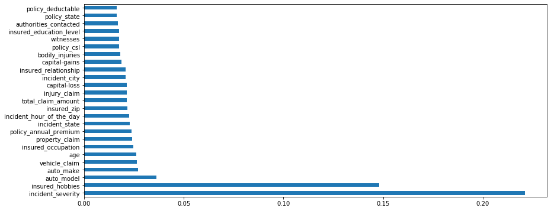

```python
plt.figure(figsize=(14,6))
feature = pd.Series(model.feature_importances_, index=X.columns)
feature.nlargest(25).plot(kind='barh')
plt.show()
```

```python
cols = ['policy_csl','umbrella_limit','insured_sex','capital-gains','collision_type','number_of_vehicles_involved',
        'property_damage','police_report_available','injury_claim']
```

```python
X.drop(cols,axis=1,inplace=True)
```

```python
X.shape
```

```
(1000, 25)
```

Step 6: Building XGBoost Model using Hyper parameter tunning because it performes better when we have a imbalanced dataset.

```python
from sklearn.model_selection import train_test_split
```

```python
X_train, X_test, y_train, y_test = train_test_split(X,y,test_size=0.3)
```

```python
from sklearn.preprocessing import StandardScaler
```

```python
scaler = StandardScaler()
```

```python
X_train = scaler.fit_transform(X_train)
X_test = scaler.fit_transform(X_test)
```

```python
print(X_train)
print(X_test)
```

```
[[-0.83583877 -1.10353075  0.71089827 ... -1.61482135 -1.35618825
  -1.65296076]
 [ 0.0325492  -0.44898632 -1.40667104 ... -0.44522597 -0.64346678
   0.17286019]
 [-0.18239832 -0.44898632  0.71089827 ...  1.21170081  1.35215317
   1.00277881]
 ...
 [-0.47472695 -0.23080484  0.71089827 ... -0.25029341 -0.95528245
  -0.98902587]
 [-1.2141464  -1.10353075  0.71089827 ... -1.61482135 -0.05276331
  -1.15500959]
 [ 2.14763276  2.49646366  0.71089827 ... -0.44522597  0.43986979
   1.16876253]]
[[-0.76566425 -1.05587168  0.72307858 ... -1.42742362 -1.29493537
  -0.24114233]
 [ 0.93223734  0.8223793   0.72307858 ... -1.23927464 -1.08636659
   0.09377757]
 [-0.02394935 -0.28247422  0.72307858 ... -1.61557261 -0.12695033
  -0.74352217]
 ...
 [-0.43502026 -0.94538633  0.72307858 ...  0.6234003   0.36037225
   1.26599721]
 [ 0.69095658  0.8223793   0.72307858 ...  0.6234003   0.36037225
   0.26123752]
 [-0.63161939 -0.94538633  0.72307858 ...  1.09377276  0.97904341
  -1.41336197]]
```

```python
from sklearn.model_selection import RandomizedSearchCV
from xgboost import XGBClassifier
```

```python
params = {"learning_rate"    : [0.05, 0.10, 0.15, 0.20, 0.25, 0.30 ] ,
          "max_depth"        : [ 3, 4, 5, 6, 8, 10, 12, 15],
          "min_child_weight" : [ 1, 3, 5, 7 ],
          "gamma"            : [ 0.0, 0.1, 0.2 , 0.3, 0.4 ],
          "colsample_bytree" : [ 0.3, 0.4, 0.5 , 0.7 ]}
```

```python
classifier = XGBClassifier()
```

```python
random_search=RandomizedSearchCV(classifier,param_distributions=params,n_iter=5,scoring='roc_auc',n_jobs=-1,cv=5)
```

```python
random_search.fit(X_train,y_train)
```

```
RandomizedSearchCV(cv=5, error_score='raise-deprecating',
                   estimator=XGBClassifier(base_score=0.5, booster='gbtree',
                                           colsample_bylevel=1,
                                           colsample_bynode=1,
                                           colsample_bytree=1, gamma=0,
                                           learning_rate=0.1, max_delta_step=0,
                                           max_depth=3, min_child_weight=1,
                                           missing=None, n_estimators=100,
                                           n_jobs=1, nthread=None,
                                           objective='binary:logistic',
                                           random_state=0, reg_alpha=0...
                                           seed=None, silent=None, subsample=1,
                                           verbosity=1),
                   iid='warn', n_iter=5, n_jobs=-1,
                   param_distributions={'colsample_bytree': [0.3, 0.4, 0.5,
                                                             0.7],
                                        'gamma': [0.0, 0.1, 0.2, 0.3, 0.4],
                                        'learning_rate': [0.05, 0.1, 0.15, 0.2,
                                                          0.25, 0.3],
                                        'max_depth': [3, 4, 5, 6, 8, 10, 12,
                                                      15],
                                        'min_child_weight': [1, 3, 5, 7]},
                   pre_dispatch='2*n_jobs', random_state=None, refit=True,
                   return_train_score=False, scoring='roc_auc', verbose=0)
```

```python
random_search.best_estimator_
```

```
XGBClassifier(base_score=0.5, booster='gbtree', colsample_bylevel=1,
              colsample_bynode=1, colsample_bytree=0.7, gamma=0.0,
              learning_rate=0.25, max_delta_step=0, max_depth=12,
              min_child_weight=7, missing=None, n_estimators=100, n_jobs=1,
              nthread=None, objective='binary:logistic', random_state=0,
              reg_alpha=0, reg_lambda=1, scale_pos_weight=1, seed=None,
              silent=None, subsample=1, verbosity=1)
```

```python
random_search.best_params_
```

```
{'min_child_weight': 7,
 'max_depth': 12,
 'learning_rate': 0.25,
 'gamma': 0.0,
 'colsample_bytree': 0.7}
```

```python
classifier = XGBClassifier(base_score=0.5, booster='gbtree', colsample_bylevel=1,
              colsample_bynode=1, colsample_bytree=0.4, gamma=0.0,
              learning_rate=0.1, max_delta_step=0, max_depth=3,
              min_child_weight=7, missing=None, n_estimators=100, n_jobs=1,
              nthread=None, objective='binary:logistic', random_state=0,
              reg_alpha=0, reg_lambda=1, scale_pos_weight=1, seed=None,
              silent=None, subsample=1, verbosity=1)
```

```python
classifier.fit(X_train,y_train)
```

```
XGBClassifier(base_score=0.5, booster='gbtree', colsample_bylevel=1,
              colsample_bynode=1, colsample_bytree=0.4, gamma=0.0,
              learning_rate=0.1, max_delta_step=0, max_depth=3,
              min_child_weight=7, missing=None, n_estimators=100, n_jobs=1,
              nthread=None, objective='binary:logistic', random_state=0,
              reg_alpha=0, reg_lambda=1, scale_pos_weight=1, seed=None,
              silent=None, subsample=1, verbosity=1)
```

```python
y_pred = classifier.predict(X_test)
```

```python
from sklearn.metrics import confusion_matrix, accuracy_score
```

```python
cm = confusion_matrix(y_pred,y_test)
```

```python
cm
```

```
array([[207,  25],
       [ 17,  51]], dtype=int64)
```

```python
accuracy = accuracy_score(y_test,y_pred)
```

```python
accuracy
```

```
0.86
```